# Data Visualization

Pisitpon Jame

2023-05-24

# Exploratory Data Analysis

## Dataset `diamonds`

```r
library(tidyverse)
glimpse(diamonds)
```

```
## Rows: 53,940
## Columns: 10
## $ carat   <dbl> 0.23, 0.21, 0.23, 0.29, 0.31, 0.24, 0.24, 0.26, 0.22, 0.23, 0.…
## $ cut     <ord> Ideal, Premium, Good, Premium, Good, Very Good, Very Good, Ver…
## $ color   <ord> E, E, E, I, J, J, I, H, E, H, J, J, F, J, E, E, I, J, J, J, I,…
## $ clarity <ord> SI2, SI1, VS1, VS2, SI2, VVS2, VVS1, SI1, VS2, VS1, SI1, VS1, …
## $ depth   <dbl> 61.5, 59.8, 56.9, 62.4, 63.3, 62.8, 62.3, 61.9, 65.1, 59.4, 64…
## $ table   <dbl> 55, 61, 65, 58, 58, 57, 57, 55, 61, 61, 55, 56, 61, 54, 62, 58…
## $ price   <int> 326, 326, 327, 334, 335, 336, 336, 337, 337, 338, 339, 340, 34…
## $ x       <dbl> 3.95, 3.89, 4.05, 4.20, 4.34, 3.94, 3.95, 4.07, 3.87, 4.00, 4.…
## $ y       <dbl> 3.98, 3.84, 4.07, 4.23, 4.35, 3.96, 3.98, 4.11, 3.78, 4.05, 4.…
## $ z       <dbl> 2.43, 2.31, 2.31, 2.63, 2.75, 2.48, 2.47, 2.53, 2.49, 2.39, 2.…
```

*Note* : Diamond clarity is a measure of the purity and rarity of the stone, graded by the visibility of these characteristics under 10-power magnification. A stone is graded as flawless if, under 10-power magnification, no inclusions (internal flaws) and no blemishes (external imperfections) are visible.

- FL diamonds are Flawless
- IF diamonds are Internally Flawless
- VVS1 VVS2 : VVS diamonds (1 and 2) are Very, Very Slightly Included
- VS1 VS2 : VS diamonds (1 and 2) are Very Slightly Included
- SI1 SI2 : SI diamonds (1 and 2) are Slightly Included
- I1 I2 I3 : I diamonds (1, 2 and 3) are Imperfect

Source : [Tiffany Diamonds](https://www.tiffany.com/engagement/the-tiffany-guide-to-diamonds/clarity/)

===============================================================================================================

### Chart 1 : Distribution of Price Seperate By Clarity

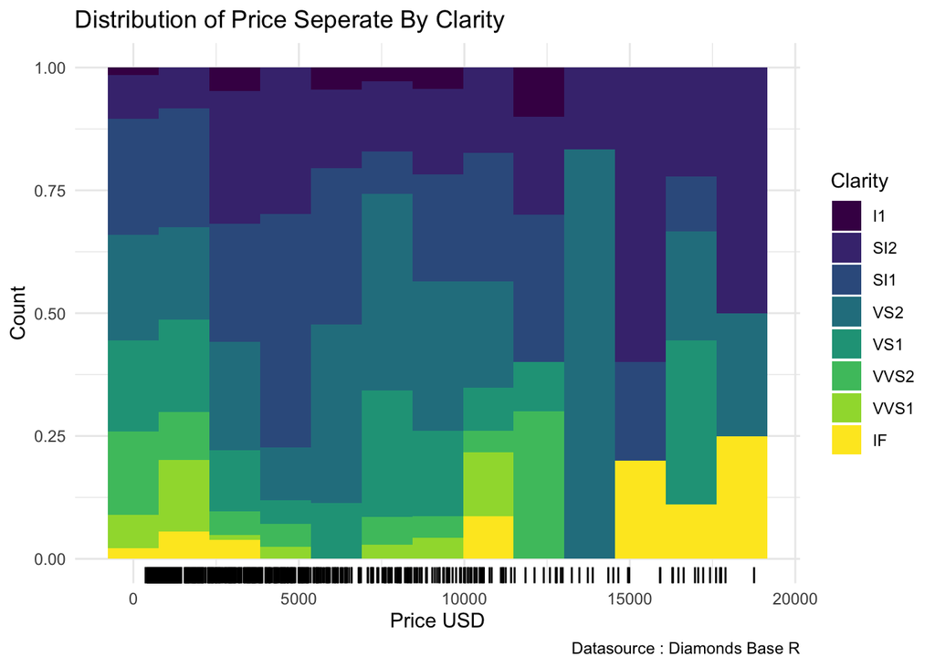

```r
set.seed(33)
ggplot(diamonds %>% sample_n(700), aes(price, fill = clarity)) +
  geom_histogram(bins = 13,position = "fill") +
  geom_rug() +
  theme_minimal() +
  labs(
    title = "Distribution of Price Seperate By Clarity",
    x = "Price USD",
    y = "Count",
    fill = "Clarity",
    caption = "Datasource : Diamonds Base R"
  )
```

This chart show the distribution of price seperated by clarity. Black bar code below the chart show the concentration of price.

===============================================================================================================

### Chart 2 : Relationship Between Carat and Price Seperate By Cut

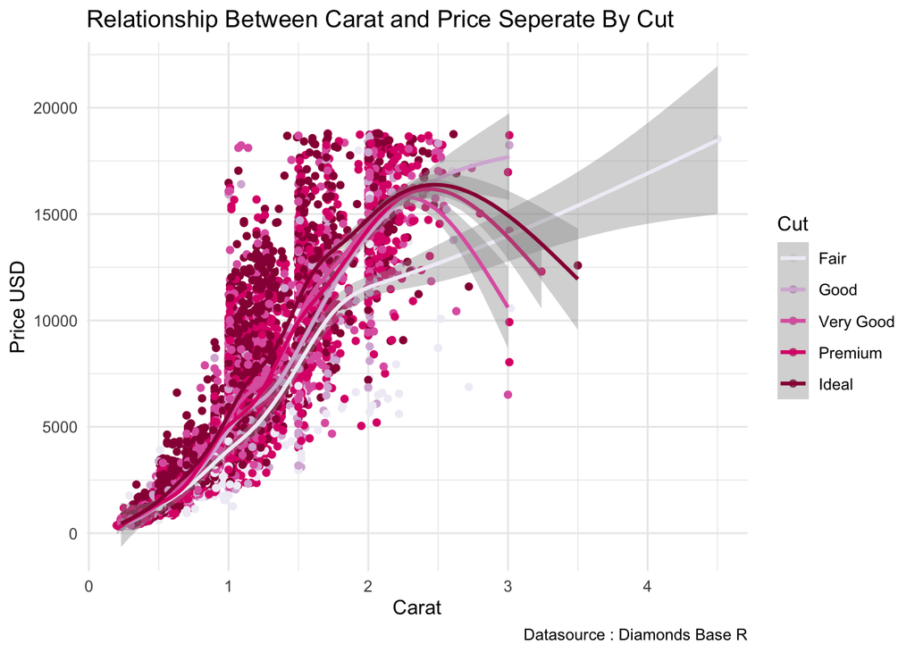

```r
set.seed(33)
ggplot(diamonds %>% sample_frac(0.3), aes(carat, price, col = cut)) +
  geom_point(alpha=1) +
  geom_smooth() +
  scale_color_brewer(type="seq", palette=11) +
  theme_minimal() +
  labs(
    title = "Relationship Between Carat and Price Seperate By Cut",
    x = "Carat",
    y = "Price USD",
    colour = "Cut",
    caption = "Datasource : Diamonds Base R"
  )
```

From this chart show a positive relationship between carat and price.

===============================================================================================================

### Chart 3 : Relationship Between Depth and Price Seperate By Cut

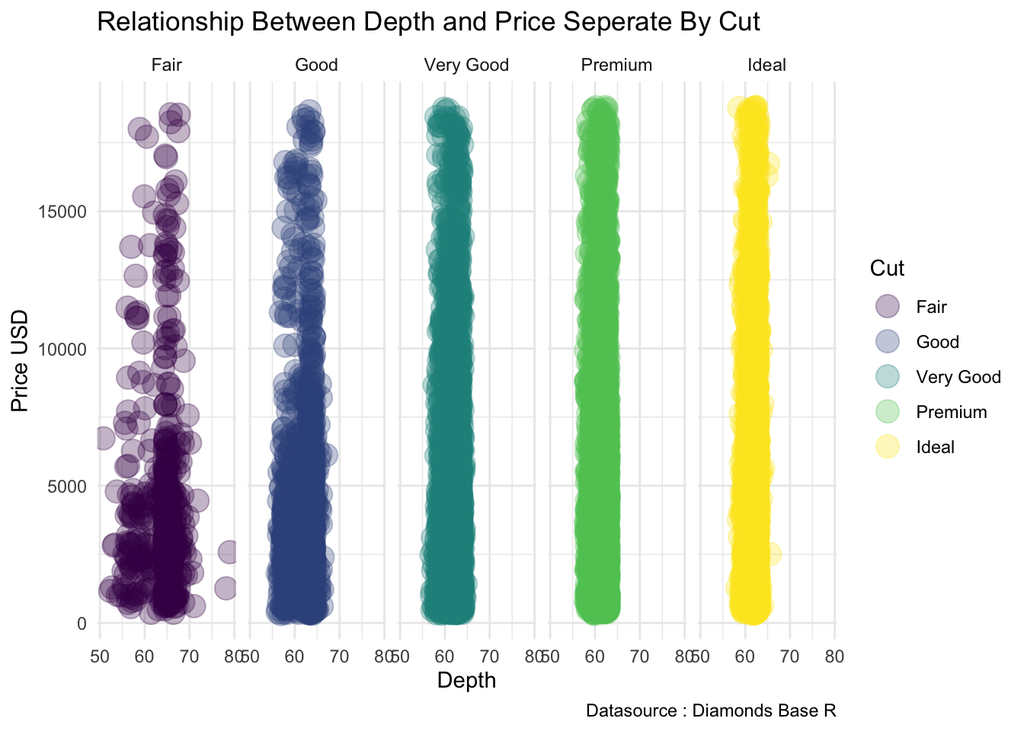

```r
set.seed(33)
ggplot(diamonds %>% sample_frac(0.3), aes(depth, price, col = cut)) +
  geom_point(size=5, alpha=0.3) +
  facet_wrap(~cut, ncol = 5) +
  theme_minimal() +
  labs(
    title = "Relationship Between Depth and Price Seperate By Cut",
    x = "Depth",
    y = "Price USD",
    colour = "Cut",
    caption = "Datasource : Diamonds Base R"
  )
```

===============================================================================================================

### Chart 4 : Relationship Between Clarity and Carat

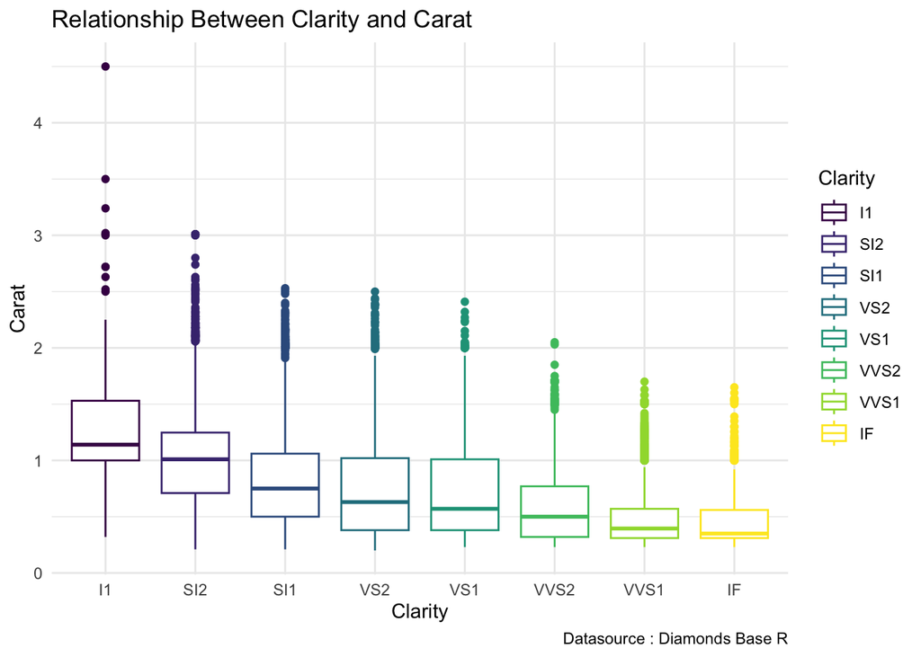

```r
set.seed(33)
ggplot(diamonds %>% sample_frac(0.3), aes(clarity, carat, col = clarity))+
  geom_boxplot() +
  theme_minimal() +
  labs(
    title = "Relationship Between Clarity and Carat",
    x = "Clarity",
    y = "Carat",
    colour = "Clarity",
    caption = "Datasource : Diamonds Base R"
  )
```

From this box plot show a relationship. Higher carat be tends less clarity.

===============================================================================================================

### Chart 5 : Relationship Between Table and Price Seperate By Cut

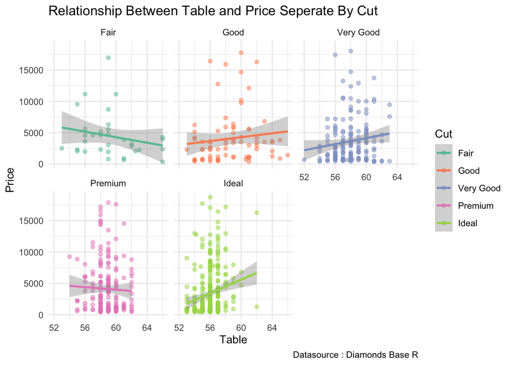

```r
set.seed(33)
ggplot(diamonds %>% sample_n(800), aes(table, price, col = cut)) +
  geom_point(alpha=0.5) +
  geom_smooth(method = "lm") +
  theme_minimal() +
  scale_color_brewer(type = "qual", palette = 7) +
  facet_wrap(~cut) +
  labs(
    title = "Relationship Between Table and Price Seperate By Cut",
    x = "Table",
    y = "Price",
    colour = "Cut",
    caption = "Datasource : Diamonds Base R"
  )
```

This chart table and price aren’t related. However when seperate and wrap with column cut will see that some cutting method price and table be related.

===============================================================================================================